# Q2 DDIM By Devendra & Rutul

#### WORK CONTRIBUTION

##### DEVENDRA SINGH SHEKHAWAT:

- Developed the reverse diffusion process to generate images from noise using the trained UNet model.
- Implemented image generation functions to efficiently sample and reconstruct images using the trained DDIM model.
- Added evaluation metrics (Inception Score, FID), initially using 100 images, later tuned for a smaller batch for efficiency.
- Fine-tuned the evaluation pipeline by resizing images to 299x299 for compatibility with InceptionV3.
- Created visualization functions to display generated images and compare them with real images.

### GENERATED IMAGES

[output not shown]

[output not shown]

[output not shown]

[output not shown]

[output not shown]

[output not shown]

[figure not shown]

[figure not shown]

# Evaluation Metrics for DDIM Model

| Metric | Score |
| --- | --- |
| **Inception Score** | 28.07892608642578 |
| **FID Score** | 241.64163435917823 |

### PROMPTS

- Give me an optimized way to load and preprocess 10,000 images from the Yelp Photos dataset, skipping corrupted ones and resizing them to 256x256.
- Give me a UNet implementation with separate encoder and decoder functions for my DDIM generative model.
- Give me an efficient implementation of the forward and reverse diffusion process for my DDIM model, ensuring that the generated images don’t turn out gray.
- Give me a function to generate and denoise images using my trained DDIM model and visualize the generated samples.
- Give me a complete implementation to calculate both Inception Score and Frechet Inception Distance (FID) for evaluating the quality of my generated images.
- Give me strategies to improve the image quality of my DDIM-generated images, such as tuning hyperparameters, increasing training epochs, or modifying the noise schedule.

##### Importing The Libraries

```python
import os
import numpy as np
import matplotlib.pyplot as plt
from tqdm import tqdm
import random
from PIL import Image
import tensorflow as tf
from tensorflow.keras.layers import Conv2D, BatchNormalization, LeakyReLU, Conv2DTranspose, Concatenate, Input, UpSampling2D, Dropout
from tensorflow.keras.models import Model
from tensorflow.keras.applications.inception_v3 import InceptionV3, preprocess_input
from scipy.linalg import sqrtm
from tensorflow.keras.preprocessing.image import img_to_array
from scipy.stats import entropy
```

##### Loading The Dataset

```python
# Path to the dataset
dataset_path = r"C:\Users\37789\Downloads\Yelp-Photos\Yelp Photos\yelp_photos\photos"
```

```python
# Function to load and preprocess exactly 10,000 random, non-corrupted images
def load_and_preprocess_images(dataset_path, img_size=(128, 128), max_images=10000):
    image_files = list(iter(os.listdir(dataset_path)))  # Get an iterator for the files
    random.shuffle(image_files)  # Shuffle before processing

    images = []
    count = 0

    print("Loading images...")
    with tqdm(total=max_images, desc="Collecting images", unit="image") as pbar:
        for image_file in image_files:
            if count >= max_images:
                break  # Stop once we reach 10,000 images

            img_path = os.path.join(dataset_path, image_file)

            try:
                # Open image using PIL
                with Image.open(img_path).convert("RGB") as img:
                    img = img.resize(img_size, Image.LANCZOS)  # Resize efficiently

                    # Convert to NumPy array and normalize to [0,1]
                    img = np.array(img, dtype=np.float32) / 255.0

                    images.append(img)
                    count += 1
                    pbar.update(1)  # Update progress bar after each image

            except Exception:
                continue  # Skip corrupted images

    images = np.array(images, dtype=np.float32)  # Convert to NumPy array
    print(f"Successfully loaded {count} non-corrupted images.")

    # Debug: Print the shape of images before using it in TensorFlow dataset
    print(f"Shape of images array: {images.shape}")

    if images.shape[0] == 0:
        raise ValueError("No valid images were loaded. Check your dataset path and images.")

    return images
```

##### Loading & Preprocessing

```python
# Load and preprocess the images with 128x128 size
images = load_and_preprocess_images(dataset_path, img_size=(128, 128), max_images=10000)
```

```
Loading images...
```

```
Successfully loaded 10000 non-corrupted images.
Shape of images array: (10000, 128, 128, 3)
```

```python
# Ensure images are a valid dataset
if len(images.shape) != 4 or images.shape[1:] != (128, 128, 3):
    raise ValueError(f"Unexpected shape {images.shape}, expected (num_samples, 128, 128, 3).")
```

```python
# Convert the dataset into a TensorFlow dataset properly
train_dataset = tf.data.Dataset.from_tensor_slices(images).shuffle(buffer_size=1000).batch(32)
```

##### Displaying Images For Verification

```python
# Function to display 5 images for verification
def display_images(images, num_images=5):
    plt.figure(figsize=(15, 10))
    for i in range(num_images):
        plt.subplot(1, num_images, i+1)
        plt.imshow(images[i])
        plt.axis('off')
    plt.show()
```

[figure not shown]

```python
# Display images for verification
display_images(images, num_images=5)
```

```python
# Now train_dataset is ready for training
print("Dataset successfully created. Training can now proceed.")
```

```
Dataset successfully created. Training can now proceed.
```

```python
# Debugging step: Print a sample from the dataset
for sample in train_dataset.take(1):
    print(f"Batch shape: {sample.shape}")
```

```
Batch shape: (32, 128, 128, 3)
```

##### Building The Encoder

```python
# Encoder function
def build_encoder(input_layer, filters=[64, 128, 256, 512]):
    skips = []
    x = input_layer

    for f in filters:
        x = Conv2D(f, kernel_size=3, strides=2, padding='same')(x)
        x = BatchNormalization()(x)
        x = LeakyReLU(negative_slope=0.2)(x)
        skips.append(x)  # Store skip connections before downsampling further

    return x, skips
```

##### Building The Bottleneck Layer

```python
# Bottleneck layer with dropout
def build_bottleneck(x):
    x = Conv2D(512, kernel_size=3, strides=1, padding='same')(x)
    x = BatchNormalization()(x)
    x = LeakyReLU(negative_slope=0.2)(x) #alpha
    x = Dropout(0.3)(x)
    return x
```

```python
# Decoder function (Ensuring shape alignment)
def build_decoder(encoded, skips, filters=[512, 256, 128, 64]):
    x = encoded

    for f, skip in zip(filters, reversed(skips)):
        x = Conv2DTranspose(f, kernel_size=3, strides=2, padding='same')(x)
        x = BatchNormalization()(x)
        x = LeakyReLU(negative_slope=0.2)(x)

        # Ensure skip connection shape matches decoder output before concatenation
        if x.shape[1] != skip.shape[1] or x.shape[2] != skip.shape[2]:
            skip = UpSampling2D(size=(2, 2))(skip)  # Adjust spatial size if needed

        x = Concatenate()([x, skip])  # Concatenate only if shapes match

    return x
```

```python
# UNet Model
def build_unet(img_size=(128, 128, 3), activation='sigmoid'):
    inputs = Input(shape=img_size)

    encoded, skips = build_encoder(inputs)
    bottleneck = build_bottleneck(encoded)
    decoded = build_decoder(bottleneck, skips)

    outputs = Conv2D(3, kernel_size=3, padding='same', activation=activation)(decoded)

    model = Model(inputs, outputs, name="UNet")

    return model
```

```python
# Create and summarize the UNet model
unet_model = build_unet()
```

```python
unet_model.summary()
```

```
Model: "UNet"
```

```
┏━━━━━━━━━━━━━━━━━━━━━━━━━━━━━━━┳━━━━━━━━━━━━━━━━━━━━━━━━━━━┳━━━━━━━━━━━━━━━━━┳━━━━━━━━━━━━━━━━━━━━━━━━━━━━┓
┃ Layer (type)                  ┃ Output Shape              ┃         Param # ┃ Connected to               ┃
┡━━━━━━━━━━━━━━━━━━━━━━━━━━━━━━━╇━━━━━━━━━━━━━━━━━━━━━━━━━━━╇━━━━━━━━━━━━━━━━━╇━━━━━━━━━━━━━━━━━━━━━━━━━━━━┩
│ input_layer (InputLayer)      │ (None, 128, 128, 3)       │               0 │ -                          │
├───────────────────────────────┼───────────────────────────┼─────────────────┼────────────────────────────┤
│ conv2d (Conv2D)               │ (None, 64, 64, 64)        │           1,792 │ input_layer[0][0]          │
├───────────────────────────────┼───────────────────────────┼─────────────────┼────────────────────────────┤
│ batch_normalization           │ (None, 64, 64, 64)        │             256 │ conv2d[0][0]               │
│ (BatchNormalization)          │                           │                 │                            │
├───────────────────────────────┼───────────────────────────┼─────────────────┼────────────────────────────┤
│ leaky_re_lu (LeakyReLU)       │ (None, 64, 64, 64)        │               0 │ batch_normalization[0][0]  │
├───────────────────────────────┼───────────────────────────┼─────────────────┼────────────────────────────┤
│ conv2d_1 (Conv2D)             │ (None, 32, 32, 128)       │          73,856 │ leaky_re_lu[0][0]          │
├───────────────────────────────┼───────────────────────────┼─────────────────┼────────────────────────────┤
│ batch_normalization_1         │ (None, 32, 32, 128)       │             512 │ conv2d_1[0][0]             │
│ (BatchNormalization)          │                           │                 │                            │
├───────────────────────────────┼───────────────────────────┼─────────────────┼────────────────────────────┤
│ leaky_re_lu_1 (LeakyReLU)     │ (None, 32, 32, 128)       │               0 │ batch_normalization_1[0][… │
├───────────────────────────────┼───────────────────────────┼─────────────────┼────────────────────────────┤
│ conv2d_2 (Conv2D)             │ (None, 16, 16, 256)       │         295,168 │ leaky_re_lu_1[0][0]        │
├───────────────────────────────┼───────────────────────────┼─────────────────┼────────────────────────────┤
│ batch_normalization_2         │ (None, 16, 16, 256)       │           1,024 │ conv2d_2[0][0]             │
│ (BatchNormalization)          │                           │                 │                            │
├───────────────────────────────┼───────────────────────────┼─────────────────┼────────────────────────────┤
│ leaky_re_lu_2 (LeakyReLU)     │ (None, 16, 16, 256)       │               0 │ batch_normalization_2[0][… │
├───────────────────────────────┼───────────────────────────┼─────────────────┼────────────────────────────┤
│ conv2d_3 (Conv2D)             │ (None, 8, 8, 512)         │       1,180,160 │ leaky_re_lu_2[0][0]        │
├───────────────────────────────┼───────────────────────────┼─────────────────┼────────────────────────────┤
│ batch_normalization_3         │ (None, 8, 8, 512)         │           2,048 │ conv2d_3[0][0]             │
│ (BatchNormalization)          │                           │                 │                            │
├───────────────────────────────┼───────────────────────────┼─────────────────┼────────────────────────────┤
│ leaky_re_lu_3 (LeakyReLU)     │ (None, 8, 8, 512)         │               0 │ batch_normalization_3[0][… │
├───────────────────────────────┼───────────────────────────┼─────────────────┼────────────────────────────┤
│ conv2d_4 (Conv2D)             │ (None, 8, 8, 512)         │       2,359,808 │ leaky_re_lu_3[0][0]        │
├───────────────────────────────┼───────────────────────────┼─────────────────┼────────────────────────────┤
│ batch_normalization_4         │ (None, 8, 8, 512)         │           2,048 │ conv2d_4[0][0]             │
│ (BatchNormalization)          │                           │                 │                            │
├───────────────────────────────┼───────────────────────────┼─────────────────┼────────────────────────────┤
│ leaky_re_lu_4 (LeakyReLU)     │ (None, 8, 8, 512)         │               0 │ batch_normalization_4[0][… │
├───────────────────────────────┼───────────────────────────┼─────────────────┼────────────────────────────┤
```

[output cut: 44 more lines]

```
│ (Conv2DTranspose)             │                           │                 │                            │
├───────────────────────────────┼───────────────────────────┼─────────────────┼────────────────────────────┤
│ batch_normalization_8         │ (None, 128, 128, 64)      │             256 │ conv2d_transpose_3[0][0]   │
│ (BatchNormalization)          │                           │                 │                            │
├───────────────────────────────┼───────────────────────────┼─────────────────┼────────────────────────────┤
│ leaky_re_lu_8 (LeakyReLU)     │ (None, 128, 128, 64)      │               0 │ batch_normalization_8[0][… │
├───────────────────────────────┼───────────────────────────┼─────────────────┼────────────────────────────┤
│ up_sampling2d_3               │ (None, 128, 128, 64)      │               0 │ leaky_re_lu[0][0]          │
│ (UpSampling2D)                │                           │                 │                            │
├───────────────────────────────┼───────────────────────────┼─────────────────┼────────────────────────────┤
│ concatenate_3 (Concatenate)   │ (None, 128, 128, 128)     │               0 │ leaky_re_lu_8[0][0],       │
│                               │                           │                 │ up_sampling2d_3[0][0]      │
├───────────────────────────────┼───────────────────────────┼─────────────────┼────────────────────────────┤
│ conv2d_5 (Conv2D)             │ (None, 128, 128, 3)       │           3,459 │ concatenate_3[0][0]        │
└───────────────────────────────┴───────────────────────────┴─────────────────┴────────────────────────────┘
```

```
 Total params: 9,380,803 (35.78 MB)
```

```
 Trainable params: 9,375,939 (35.77 MB)
```

```
 Non-trainable params: 4,864 (19.00 KB)
```

```python
# ------------------------
# DDIM: Generate Noise Schedule
# ------------------------

def generate_noise_schedule(T, beta_start=1e-4, beta_end=0.02):
    betas = np.linspace(beta_start, beta_end, T, dtype=np.float32)
    alphas = 1.0 - betas
    alphas_cumprod = np.cumprod(alphas)

    # Reshape for broadcasting compatibility
    betas = betas.reshape(T, 1, 1, 1)
    alphas = alphas.reshape(T, 1, 1, 1)
    alphas_cumprod = alphas_cumprod.reshape(T, 1, 1, 1)

    return betas, alphas, alphas_cumprod
```

```python
# Set diffusion steps
T = 1000
betas, alphas, alphas_cumprod = generate_noise_schedule(T)
```

```python
# ------------------------
# DDIM: Forward Diffusion Process
# ------------------------

def forward_diffusion(x_0, betas, T):
    t = np.random.randint(0, T)  # Pick a random timestep
    noise = np.random.randn(*x_0.shape).astype(np.float32)

    alpha_t = np.sqrt(alphas_cumprod[t])
    beta_t = np.sqrt(1.0 - alphas_cumprod[t])

    x_t = alpha_t * x_0 + beta_t * noise
    return x_t, noise, t
```

```python
# ------------------------
# DDIM: Training Step
# ------------------------

def train_step(model, x_0, optimizer, loss_fn, betas, alphas_cumprod, T):
    with tf.GradientTape() as tape:
        # Forward diffusion
        x_t, noise, t = forward_diffusion(x_0, betas, T)

        # Model prediction (predict noise)
        pred_noise = model(x_t, training=True)

        # Compute loss (MSE loss between actual noise and predicted noise)
        loss = loss_fn(noise, pred_noise)

    # Backpropagation
    gradients = tape.gradient(loss, model.trainable_variables)
    optimizer.apply_gradients(zip(gradients, model.trainable_variables))

    return loss
```

```python
def train_ddim(model, dataset, betas, T, epochs=10, batch_size=32, checkpoint_dir="C:\\Users\\37789\\Downloads\\Checkpoints DDIM", start_epoch=0):
    optimizer = tf.keras.optimizers.Adam(learning_rate=1e-4)
    loss_fn = tf.keras.losses.MeanSquaredError()

    # Prepare dataset batches
    dataset = tf.data.Dataset.from_tensor_slices(dataset)
    dataset = dataset.batch(batch_size, drop_remainder=True).shuffle(1000)

    # Load checkpoint (Fix applied here)
    checkpoint = tf.train.Checkpoint(model=model)  # Removed optimizer from checkpoint
    checkpoint_prefix = os.path.join(checkpoint_dir, "checkpoint")

    latest_checkpoint = tf.train.latest_checkpoint(checkpoint_dir)
    if latest_checkpoint:
        print(f"Restoring from checkpoint: {latest_checkpoint}")
        checkpoint.restore(latest_checkpoint).expect_partial()  # Ignore optimizer warnings
    else:
        print("No checkpoint found, starting from scratch.")

    for epoch in range(start_epoch, epochs):
        print(f"Epoch {epoch+1}/{epochs}")
        epoch_loss = 0.0

        for batch in tqdm(dataset, desc=f"Training Epoch {epoch+1}"):
            loss = train_step(model, batch, optimizer, loss_fn, betas, alphas_cumprod, T)
            epoch_loss += loss.numpy()

        avg_loss = epoch_loss / len(dataset)
        print(f"Epoch {epoch+1} Loss: {avg_loss:.6f}")

        # Save checkpoint every 5 epochs
        if (epoch + 1) % 5 == 0:
            checkpoint.save(file_prefix=checkpoint_prefix)
            print(f"Checkpoint saved at epoch {epoch+1}")

    return model
```

```python
# ------------------------
# DDIM: Reverse Diffusion Process (Sampling)
# ------------------------
def reverse_diffusion(model, noisy_image, betas, alphas_cumprod, T):
    # Ensure the input shape is (1, height, width, channels)
    if len(noisy_image.shape) == 3:  # If shape is (height, width, channels)
        noisy_image = np.expand_dims(noisy_image, axis=0)  # Add batch dimension to make it (1, height, width, channels)

    print(f"Reverse Diffusion: noisy_image shape: {noisy_image.shape}")  # Initial shape info

    # Create a progress bar using tqdm
    for t in tqdm(reversed(range(T)), desc="Reverse Diffusion", total=T, ncols=100):
        # Get the model's prediction (predicted noise)
        pred_noise = model(noisy_image, training=False)  # Ensure inference mode (no dropout)

        # Compute alphas and betas for the current timestep t
        alpha_t = np.sqrt(alphas_cumprod[t])  # Alpha for timestep t
        beta_t = np.sqrt(1.0 - alphas_cumprod[t])  # Beta for timestep t

        # Reverse step: Remove noise gradually
        noisy_image = (noisy_image - beta_t * pred_noise) / alpha_t

    # Return the final generated image (remove batch dimension if needed)
    return np.squeeze(noisy_image, axis=0)  # Return shape (height, width, channels)
```

```python
# Load dataset (Assuming you have already preprocessed and loaded images into `images`)
train_dataset = images  # Ensure this is a NumPy array or a TensorFlow Dataset
```

```python
start_epoch = 15 # Example: Start from epoch 15
```

```python
trained_model = train_ddim(unet_model, train_dataset, betas, T, epochs=15, start_epoch=start_epoch)
```

```
Restoring from checkpoint: C:\Users\37789\Downloads\Checkpoints DDIM\checkpoint-3
```

```python
def generate_and_denoise_image(model, images, betas, alphas_cumprod, T):
    # Pick a random image from the dataset
    sample_image = images[np.random.randint(0, len(images))]  # Shape: (128, 128, 3)

    # Add batch dimension (needed for diffusion functions)
    sample_image = np.expand_dims(sample_image, axis=0)  # Shape: (1, 128, 128, 3)

    # Apply forward diffusion to create a noisy image
    noisy_image, _, _ = forward_diffusion(sample_image, betas, T)

    # Check shape
    print(f"Noisy image shape before passing to reverse_diffusion: {noisy_image.shape}")

    # Now pass it to the reverse diffusion function
    generated_image = reverse_diffusion(model, noisy_image[0], betas, alphas_cumprod, T)

    return sample_image[0], noisy_image[0], generated_image
```

```python
# Assuming you've already defined betas, alphas_cumprod, T, and the UNet model:
original, noisy, denoised = generate_and_denoise_image(unet_model, images, betas, alphas_cumprod, T)
```

```
Noisy image shape before passing to reverse_diffusion: (1, 128, 128, 3)
Reverse Diffusion: noisy_image shape: (1, 128, 128, 3)
```

```python
# ------------------------
# Image Generation using Reverse Diffusion
# ------------------------
def generate_images(model, betas, alphas_cumprod, T, num_images=1):
    generated_images = []
    for _ in range(num_images):
        # Generate a random sample image (noise) with the same shape as your original images
        sample_image = np.random.randn(1, 128, 128, 3)  # (batch_size, height, width, channels)

        # Apply reverse diffusion to generate the image
        generated_image = reverse_diffusion(model, sample_image[0], betas, alphas_cumprod, T)

        # Append the generated image to the list
        generated_images.append(generated_image)

    return np.array(generated_images)
```

```python
def inception_score(images, num_classes=1000):
    # Load InceptionV3 model pre-trained on ImageNet
    inception_model = InceptionV3(include_top=True, weights='imagenet')

    # Preprocess images to the format required by InceptionV3
    images = np.array([img_to_array(img) for img in images])
    images = tf.image.resize(images, (299, 299))  # Resize to 299x299 as required by InceptionV3

    # Preprocess images using the function provided by InceptionV3
    images = preprocess_input(images)

    # Get the predictions (probabilities)
    preds = inception_model.predict(images)

    # Calculate Inception Score
    kl_divergence = []
    for i in range(len(preds)):
        p_y = preds[i]
        p_y_given_x = p_y / np.sum(p_y)
        kl_divergence.append(entropy(p_y_given_x))

    # Inception score is the mean of the KL divergence values
    return np.exp(np.mean(kl_divergence))
```

```python
# Example: Generate 5 image and calculate the Inception Score
generated_images = generate_images(unet_model, betas, alphas_cumprod, T, num_images=5)

# Calculate the Inception Score for the generated image
inception_score_value = inception_score(generated_images)
print(f"Inception Score: {inception_score_value}")
```

```
Reverse Diffusion: noisy_image shape: (1, 128, 128, 3)
```

```
Reverse Diffusion: noisy_image shape: (1, 128, 128, 3)
```

```
Reverse Diffusion: noisy_image shape: (1, 128, 128, 3)
```

```
Reverse Diffusion: noisy_image shape: (1, 128, 128, 3)
```

```
Reverse Diffusion: noisy_image shape: (1, 128, 128, 3)
```

```
1/1 ━━━━━━━━━━━━━━━━━━━━ 5s 5s/step
Inception Score: 28.07892608642578
```

```python
def calculate_fid(real_images, generated_images):
    # Load the pre-trained InceptionV3 model (without the top layer)
    inception_model = InceptionV3(include_top=False, weights='imagenet', pooling='avg')

    # Preprocess images to match the input format of InceptionV3
    real_images_resized = tf.image.resize(real_images, (299, 299))  # Resize to 299x299
    generated_images_resized = tf.image.resize(generated_images, (299, 299))  # Resize to 299x299

    # Apply the preprocess_input explicitly
    real_images_resized = preprocess_input(real_images_resized)
    generated_images_resized = preprocess_input(generated_images_resized)

    # Extract features from InceptionV3 model
    real_features = inception_model.predict(real_images_resized)
    generated_features = inception_model.predict(generated_images_resized)

    # Calculate mean and covariance of real and generated features
    mu_real = np.mean(real_features, axis=0)
    mu_generated = np.mean(generated_features, axis=0)
    sigma_real = np.cov(real_features, rowvar=False)
    sigma_generated = np.cov(generated_features, rowvar=False)

    # Calculate the Frechet Inception Distance (FID)
    diff = mu_real - mu_generated
    covmean, _ = sqrtm(sigma_real.dot(sigma_generated), disp=False)
    fid = np.sum(diff**2) + np.trace(sigma_real + sigma_generated - 2 * covmean)

    return fid
```

```python
def display_images(images, num_images=5):
    fig, axes = plt.subplots(1, num_images, figsize=(15, 15))

    for i in range(num_images):
        ax = axes[i]
        ax.imshow(images[i])
        ax.axis('off')

    plt.show()
```

```python
# Generate images (change num_images to 10 or more if you want to test with more images)
generated_images = generate_images(unet_model, betas, alphas_cumprod, T, num_images=5)
```

```
Reverse Diffusion: noisy_image shape: (1, 128, 128, 3)
```

```
Reverse Diffusion: noisy_image shape: (1, 128, 128, 3)
```

```
Reverse Diffusion: noisy_image shape: (1, 128, 128, 3)
```

```
Reverse Diffusion: noisy_image shape: (1, 128, 128, 3)
```

```
Reverse Diffusion: noisy_image shape: (1, 128, 128, 3)
```

```python
# Load a subset of real images (use the original dataset, here it's assumed as `real_images`)
real_images = np.array(images[:5])  # Example: Use the first 5 real images from your dataset
```

```python
# Calculate FID score between generated and real images
fid_score = calculate_fid(real_images, generated_images)
print(f"FID Score: {fid_score}")
```

```
1/1 ━━━━━━━━━━━━━━━━━━━━ 5s 5s/step
1/1 ━━━━━━━━━━━━━━━━━━━━ 1s 601ms/step
FID Score: 241.64163435917823
```

```python
print(f"Generated images shape: {generated_images.shape}")
print(f"First image shape: {generated_images[0].shape}")
```

```
Generated images shape: (5, 128, 128, 3)
First image shape: (128, 128, 3)
```

```python
generated_images = np.clip(generated_images, 0.0, 1.0)
```

```python
# Normalize images to be in the range [0, 1] if they are not already
generated_images = np.clip(generated_images, 0.0, 1.0)
```

```python
generated_images = generated_images.astype(np.float32)  # Ensure correct data type
```

```
Reverse Diffusion: noisy_image shape: (1, 128, 128, 3)
```

```
Reverse Diffusion: noisy_image shape: (1, 128, 128, 3)
```

```
Reverse Diffusion: noisy_image shape: (1, 128, 128, 3)
```

```
Reverse Diffusion: noisy_image shape: (1, 128, 128, 3)
```

```
Reverse Diffusion: noisy_image shape: (1, 128, 128, 3)
```

[output not shown]

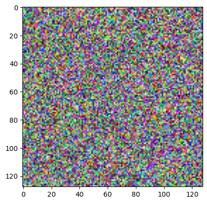

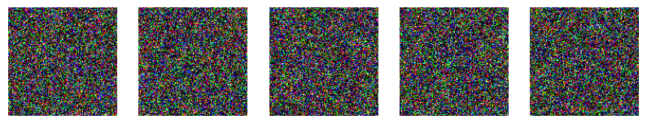

```python
# Test with a random image
test_image = np.random.rand(128, 128, 3)  # A random image for testing
plt.imshow(test_image)# Generate 5 images
generated_images = generate_images(unet_model, betas, alphas_cumprod, T=10, num_images=5)

# Display the generated images
def display_images(images, num_images=5):
    plt.figure(figsize=(10, 10))  # Adjust the size of the figure
    for i in range(min(num_images, len(images))):
        plt.subplot(1, num_images, i + 1)  # Arrange in a row
        plt.imshow(images[i])  # Display each image
        plt.axis('off')  # Hide axis
    plt.show()

# Display 5 generated images
display_images(generated_images, num_images=5)

plt.axis('off')
plt.show()
```

------------------------- END ----------------------------